# Phenotypic Linkage Network Demonstration

Cynthia Sandor & Viola Volpato

Last update: Mon Feb 10 15:28:27 2020

## Sept up your work environnement

To evaluate a the phenotypic linkage network you must:

1. Install some R/Bioconductor package
2. Indicate a directory where you will download PLN directory (require ~10Gb on your disk)
3. Indicate a list of genes (format gene symbol)

### The following package must to be installed

You must install the following packages and load them. To install a general R package you must type: install.packages(“gridExtra”) To install a Bioconductor R package you must type: BiocManager::install(“biomaRt”). You must install before BiocManager: install.packages(“BiocManager”)

[output not shown]

### Work directory

You must indicate a work directory where the PLN file will be downloaded

You must download the following tar.gz including all the PLN file in your work directory: [pln.tar.gz](https://drive.google.com/open?id=1wDFoldeFf8JjiWRhc2IjEtKhZ0nVtFwp)

### List of genes

You must specify where is your list of gene

|  | V1 |
| --- | --- |
| 1 | KLHL29 |
| 2 | ATAD2B |
| 3 | UBXN2A |
| 4 | MFSD2B |
| 5 | C2orf44 |
| 6 | FKBP1B |
| 7 | SF3B14 |
| 8 | FAM228B |
| 9 | TP53I3 |
| 10 | PFN4 |

[output cut: 136 more lines]

### Set up the parameters

Here the parameters requiry to evaluate the functional links between your list of genes by using PLN

[output not shown]

[output cut: 136 more lines]

### Functional dataset used

We used the final linkage network build with the following dataset

|  | File | Type | Coverage |
| --- | --- | --- | --- |
| 1 | Iacobuzio_2003_ordered_ord_filter_0.4_sort.general.rescore | Coexpression_Iacobuzio | 13906512 |
| 2 | Julia_GTEx_corrected_0.4_sort.general.rescore | Coexpression_GTEx | 13509482 |
| 3 | RNASeq_CorrelNet_pos_Excl_Less1Q95RPKM_sort.general.rescore | Coexpression_Brainspan | 18756277 |
| 4 | Shyamsundar_2005_ordered_ord_filter_0.4_sort.general.rescore | Coexpression_Shyamsundar | 15792065 |
| 5 | cdrbi_ordered_ho_sort.general.rescore | Protein_Protein_Interactions | 144806 |
| 6 | co_translation_ens_T0.4.ord_sort.general.rescore | Proteome | 10283832 |
| 7 | goa_bp_resg_av_ordered_filter_3.0_sort.general.rescore | GO_BiologicalProcess | 5965406 |
| 8 | goa_cc_resg_av_ordered_filter_4.0_sort.general.rescore | GO_CellularComponent | 2226170 |
| 9 | goa_mf_resg_av_ordered_filter_4.0_sort.general.rescore | GO_MolecularFunction | 1743034 |
| 10 | goa_mouse_ho_bp_resg_av_ordered_filter_3.0_sort.general.rescore | GO_Mouse_BiologicalProcess | 3676416 |

[output cut: 7 more lines]

## Functionnal Clustering

We run a Rscript to evaluate and represent the functional relationship between gene set. There are two part displayed in two different plot:

Plot1: Histogramm

We evaluates whether a given set of genes demonstrate unusually similar functionality. It examines the extent to which those genes cluster within the PLN. For this, it compares the sum of weighted links observed between these genes as compared to an equal number of random genes and computes an empirical p-value. As the coding-sequence (CDS) length and the network connectivity (degree) can bias functional network associations, the randomized genes are matched in CDS length and the degree to the original genes.

Plot2: Gene network representation

It extracts the most contributing resources, among the integrated datasets to build a PLN, for any functional associations found; (3) represents the extracted subnetwork with links colored by the most contributing resource.

```
## Cache found
```

```
## Cache found
```

[output not shown]

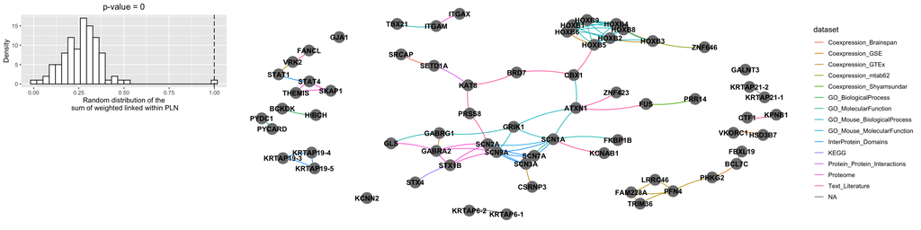